# Parcial 2.

Estadistica Computacional. Curso 2021-2022.

Carlota Valdivia Manzano.

2 de Junio de 2022.

## Ejercicio 1

Construimos un diagrama de cajas de la variable radiación solar (Solar.R) que permita comparar la distribución de sus valores en los meses de mayo, junio, julio, agosto y septiembre.

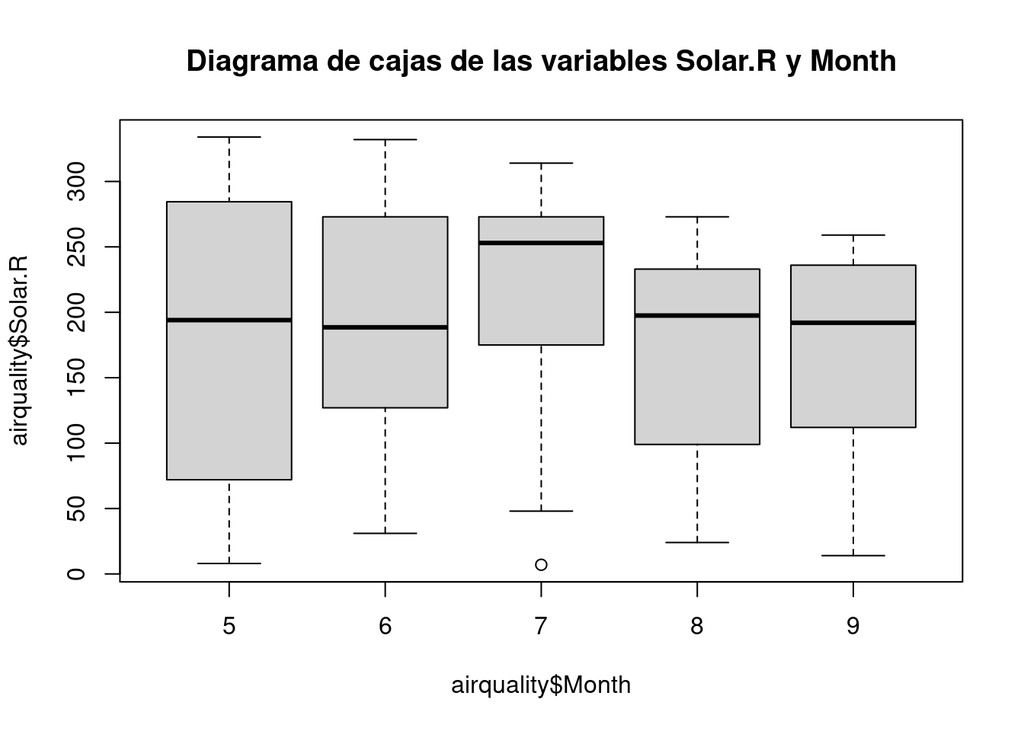

```r
boxplot(airquality$Solar.R~airquality$Month, main = "Diagrama de cajas de las variables Solar.R y Month")
```

Cosntruimos un diagrama de dispersión que permita visualizar la posible relación entre: la radiación solar, Solar.R (eje horizontal) y el contaminante Ozone (eje vertical).

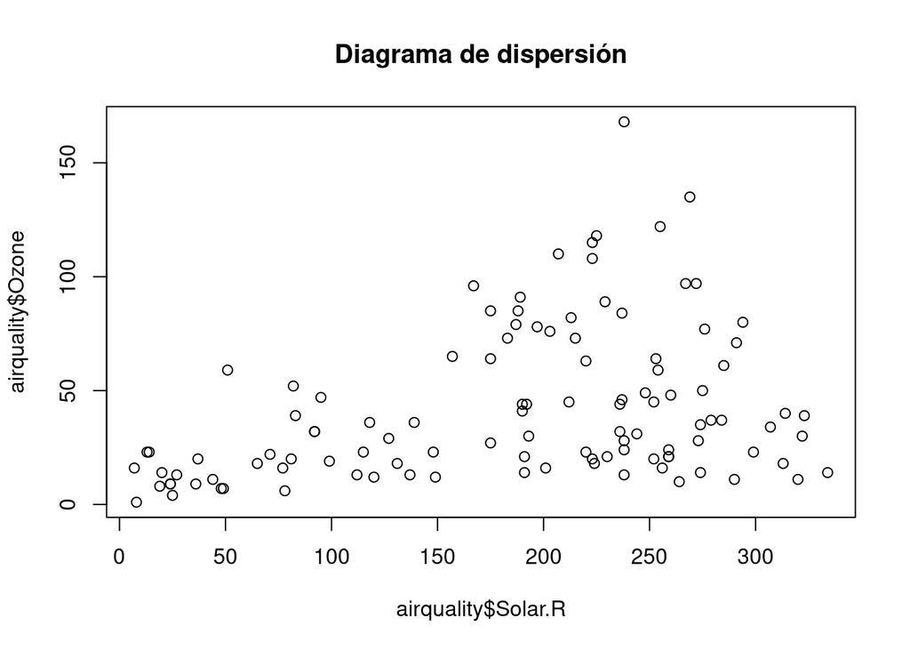

```r
plot(airquality$Solar.R, airquality$Ozone, main = "Diagrama de dispersión")
```

Ajustamos a los datos del diagrama de dispersión anterior la recta de regresión y la superponemos en el gráfico.

```r
mod<-lm(airquality$Ozone ~ 1 + airquality$Solar.R)
```

Representamos el modelo ajustado sobre el diagrama de dispersión anterior

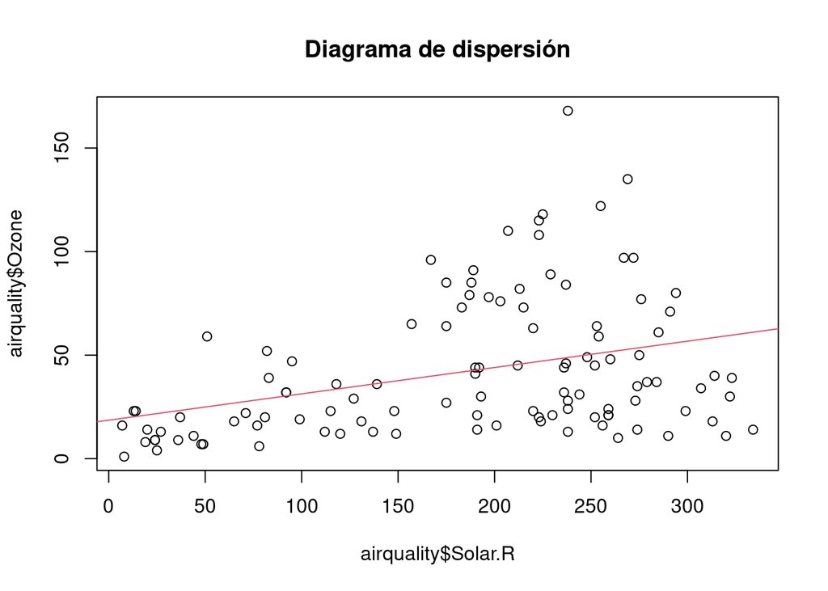

```r
plot(airquality$Solar.R, airquality$Ozone, main = "Diagrama de dispersión")
abline(mod, col="2")
```

Borramos memoria

```r
rm(list=ls(all=TRUE))
```

## Ejercicio 2

Utilizando el método de inversión vamos a generar n=1000 valores de una distribución Pareto con parámetros a=5 y b=4.

```r
n<-1000
a<-5
b<-4

set.seed(1)
u<-runif(n)
```

Evaluamos usando gráficos y el contraste de Kolmogorov-Smirnow que en efecto los valores generados provienen de dicha distribución.

```r
inversa.pareto<-function(u, a, b) {
  (b/(1-u)^(1/a))
}

x<-inversa.pareto(u,a,b)
```

Calculamos la funciones de densidad y distribución

```r
f.densidad<-function(x, a, b) {
  ifelse(x>=b, (a*b^a)/(x^(a+1)), 0)
}

f.distribucion<-function(x, a, b) {
  ifelse(x>=b, 1-(b/x)^a, 0)
}
```

Creamos el gráfico, y comprobamos que los valores que hemos generado corresponde a los de la distribución. Para ello vamos a representar los valores de la distribución mediante un histograma, la densidad suavizada y la densidad real.

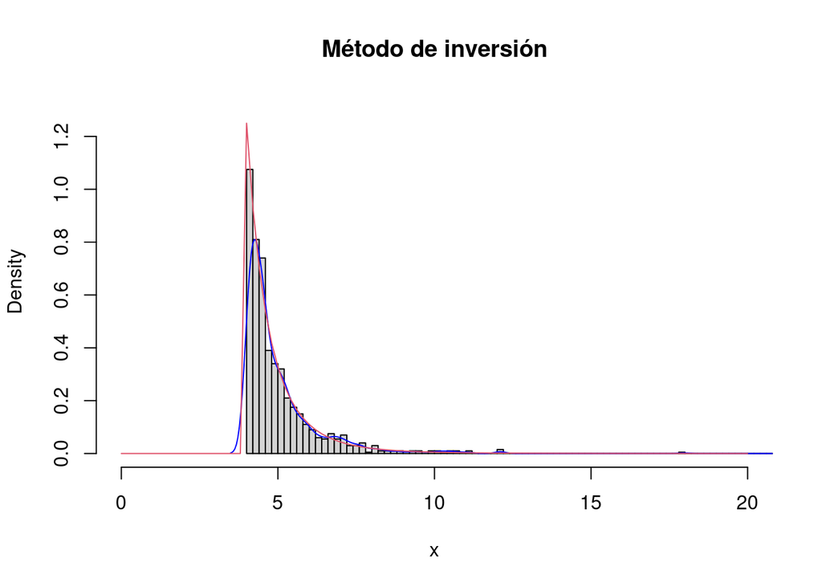

```r
hist(x, breaks="FD", freq=FALSE, main="Método de inversión", xlim=c(0,20),ylim=c(0,1.3))
lines(density(x), col="blue")
curve(f.densidad(x,a,b),add=TRUE,col=2)
```

Evaluamos el contraste de Kolmogorov-Smirnow

```r
ks.test(x,f.distribucion,a=a,b=b)
```

```
##
##  One-sample Kolmogorov-Smirnov test
##
## data:  x
## D = 0.024366, p-value = 0.5928
## alternative hypothesis: two-sided
```

Podemos apreciar que el p-valor nos dice que no se aprecian desviaciones de la hipótesis nula planteada.

Borramos memoria

```r
rm(list=ls(all=TRUE))
```